# Ejercicios resueltos

Samuel D. Gamboa Tuz

12/7/2021

Respuesta a los [ejercicios](https://github.com/sdgamboa/COURSES/blob/main/INTRO_R/scripts/ciatej2021/ejercicio1.R) del módulo de introducción a R.

Carguemos los paquetes necesarios:

```r
library(readr)
library(readxl)
library(dplyr)
library(tidyr)
library(ggplot2)
library(ggrepel)
library(forcats)
```

## Descargar e importar archivos

Los datos para estos ejercicios serán los mismos que utilizamos durante las sesiones en clase:

- El archivo con los *fold change* comparando L-CN (hoja control) vs L-20 (hoja después de 20 días de sequía). Liga: https://raw.githubusercontent.com/sdgamboa/misc_datasets/master/L0_vs_L20.tsv
- El archivo con la matriz de TPM y los identificadores completos de los genes: https://static-content.springer.com/esm/art%3A10.1038%2Fs41598-018-32904-2/MediaObjects/41598_2018_32904_MOESM3_ESM.xlsx

La fuente de estos datos es: https://doi.org/10.1038/s41598-018-32904-2

Guardemos las ligas en un *character string*. En el código de abajo, utilicé `paste0` solo para que la liga no ocupe más de 80 columnas (esto puede ayudar a que el código sea más cómodo de leer).

```r
## URL to the Fold change file
fc_url <- paste0(
  "https://raw.githubusercontent.com/sdgamboa/misc_datasets/master/",
  "L0_vs_L20.tsv"
)

## URL to the count matrix file
mat_url <- paste0(
  "https://static-content.springer.com/esm/",
  "art%3A10.1038%2Fs41598-018-32904-2/MediaObjects/",
  "41598_2018_32904_MOESM3_ESM.xlsx"
)
```

Utilicemos `download.file` para descargar los archivos en el directorio de trabajo actual (se puede consultar con `getwd` o cambiar con `setwd`).

```r
fc_file <- "fc_file.tsv"
mat_file <- "mat_file.xlsx"

if (!file.exists(fc_file))
  download.file(fc_url, fc_file)

if (!file.exists(mat_file))
  download.file(mat_url, mat_file)
```

El archivo “fc_file.tsv” es un arhivo delimitado por tabs (.tsv) así que podemos usar la función `read_tsv` del paquete `readr` para importar el archivo:

```r
fc_data <- read_tsv(fc_file, show_col_types = FALSE)
head(fc_data)
```

```
## # A tibble: 6 × 4
##   Genes   logFC   PValue      FDR
##   <chr>   <dbl>    <dbl>    <dbl>
## 1 276_4  -10.5  1.60e-61 3.35e-57
## 2 62_157  -9.32 6.98e-54 7.31e-50
## 3 144_7   12.2  2.42e-53 1.69e-49
## 4 198_6  -10.0  3.31e-53 1.73e-49
## 5 829_3   11.9  2.98e-51 1.25e-47
## 6 44_124  -8.91 2.98e-50 1.04e-46
```

El archivo contiene cuatro columnas:

| Columna | Descripción |
| --- | --- |
| Genes | La columna con los identificadores de los genes. |
| logFC | Log2 del *Fold Change*. |
| PValue | El P-value por gen. A menor valor, mayor significancia. |
| FDR | El P-value ajustado. |

El archivo “mat_file.xlsx” es un archivo de excel por lo que necesitamos la función `read_xlsx` del paquete `readxl` para importar el archivo:

```r
mat <- read_xlsx(
    path = mat_file, range = "Supplementary Table S2!A5:AQ27774"
) %>%
  select(Cpapaya_ID, `L-CNa`:last_col())

glimpse(mat)
```

```
## Rows: 27,769
## Columns: 19
## $ Cpapaya_ID <chr> "evm.TU.contig_23646", "evm.TU.contig_23646.1", "evm.TU.con…
## $ `L-CNa`    <dbl> 0.0000000, 0.0000000, 0.0000000, 0.0000000, 0.0000000, 0.00…
## $ `L-CNb`    <dbl> 0.00000000, 0.00000000, 0.00000000, 0.00000000, 0.00000000,…
## $ `L-10a`    <dbl> 0.00000000, 0.00000000, 0.00000000, 0.00000000, 0.00000000,…
## $ `L-10b`    <dbl> 0.00000000, 0.00000000, 0.00000000, 0.00000000, 0.00000000,…
## $ `L-20a`    <dbl> 0.00000000, 0.00000000, 0.00000000, 0.00000000, 0.00000000,…
## $ `L-20b`    <dbl> 0.0000000, 0.0000000, 0.0000000, 0.0000000, 0.0000000, 0.00…
## $ `S-CNa`    <dbl> 0.00000000, 0.00000000, 0.00000000, 0.00000000, 0.00000000,…
## $ `S-CNb`    <dbl> 0.0000000, 0.0000000, 0.0000000, 0.0000000, 0.1285914, 0.00…
## $ `S-10a`    <dbl> 0.0000000, 0.0000000, 0.0000000, 0.0000000, 0.0000000, 0.00…
## $ `S-10b`    <dbl> 0.000000, 0.000000, 0.000000, 0.000000, 0.000000, 0.000000,…
## $ `S-20a`    <dbl> 0.00000000, 0.00000000, 0.00000000, 0.00000000, 0.00000000,…
## $ `S-20b`    <dbl> 0.00000000, 0.00000000, 0.00000000, 0.00000000, 0.00000000,…
## $ `R-CNa`    <dbl> 0.00000000, 0.00000000, 0.00000000, 0.00000000, 0.00000000,…
## $ `R-CNb`    <dbl> 0.0000000, 0.0000000, 0.0000000, 0.0000000, 0.0000000, 0.00…
## $ `R-10a`    <dbl> 0.0000000, 0.0000000, 0.0000000, 0.0000000, 0.0000000, 0.00…
## $ `R-10b`    <dbl> 0.0000000, 0.0000000, 0.0000000, 0.0000000, 0.0000000, 0.00…
## $ `R-20a`    <dbl> 0.00000000, 0.00000000, 0.00000000, 0.00000000, 0.00000000,…
## $ `R-20b`    <dbl> 0.00000000, 0.00000000, 0.00000000, 0.00000000, 0.00000000,…
```

El archivo original contiene muchas columnas, pero con la línea `select(Cpapaya_ID,`L-CNa`:last_col())` solo seleccionamos las columnas de interés:

| Columna | Descripción |
| --- | --- |
| Cpapaya_ID | Contiene los indentificadores completos de los genes. Está relacionada a la columna “Genes” en el archivo “fc_file.tsv”. |
| L-CNa - R-20b | Valores de TPM por réplica (duplicados). L: hoja, R: Raiz, S: Savia; CN: control, 10 y 20: días de sequía; a y b: duplicados. |

## Ejercicio 1.1

> Econtrar los genes signigicativos UP and DOWN a diferentes thresholds de significancia (FDR 0.1, 0.05, 0.001, FC > 2). Hacer gráfico de barras comparativo.

El número de genes regulados significativamente va a depender de los thresholds que establezcamos. Por ejemplo, un threshold de FDR=0.001 es más estringente que un threshold de FDR=0.1, por lo que menos genes serían catalogados como significativos en el primer caso.

Vamos a etiquetar los genes como:

- “Up-regulated”, o regulados hacia, si tienen un fold change (FC) mayor o igual que 2 y un FDR menor a un threshold determinado.
- “Down-regulated”, o regulados hacia abajo, si tienen un FC menor o igual que -2 y un FDR menor a un threshold determinado.
- “Unchanged”, o sin cambios, si no tienen relevancia significativa.

Usaremos tres valores de threshold: 0.001, 0.05, y 0.1.

Definamos una función para ayudarnos a etiquetar los genes:

```r
label_sig <- function(fdr_vctr, fc_vctr, fdr, fc = 2) {
  dplyr::case_when(
    fdr_vctr <= fdr & fc_vctr >= log(fc) ~ "Up-regulated",
    fdr_vctr <= fdr & fc_vctr <= -log(fc) ~ "Down-regulated",
    TRUE ~ "Unchanged"
  )
}
```

Utilicemos mutate para crear nuevas columnas con las etiquetas. Luego las cambiamos a formato tidy con `pivot_longer`:

```r
fc_data <- fc_data %>%
  mutate(
    sig_001 = label_sig(FDR, logFC, 0.001),
    sig_05 = label_sig(FDR, logFC, 0.05),
    sig_1 = label_sig(FDR, logFC, 0.1)
  ) %>%
      pivot_longer(
        names_to = "sig_threshold", values_to = "sig_label",
        cols = sig_001:sig_1
    )
glimpse(fc_data)
```

```
## Rows: 62,835
## Columns: 6
## $ Genes         <chr> "276_4", "276_4", "276_4", "62_157", "62_157", "62_157",…
## $ logFC         <dbl> -10.511825, -10.511825, -10.511825, -9.317522, -9.317522…
## $ PValue        <dbl> 1.597352e-61, 1.597352e-61, 1.597352e-61, 6.982557e-54, …
## $ FDR           <dbl> 3.345653e-57, 3.345653e-57, 3.345653e-57, 7.312483e-50, …
## $ sig_threshold <chr> "sig_001", "sig_05", "sig_1", "sig_001", "sig_05", "sig_…
## $ sig_label     <chr> "Down-regulated", "Down-regulated", "Down-regulated", "D…
```

Para el primer ejercicio usemos `count` de `dplyr` para contar los números de genes de acuerdo a las etiquetas:

```r
fc_counts <- fc_data %>%
  count(sig_threshold, sig_label)
fc_counts
```

```
## # A tibble: 9 × 3
##   sig_threshold sig_label          n
##   <chr>         <chr>          <int>
## 1 sig_001       Down-regulated  1259
## 2 sig_001       Unchanged      18887
## 3 sig_001       Up-regulated     799
## 4 sig_05        Down-regulated  2559
## 5 sig_05        Unchanged      16317
## 6 sig_05        Up-regulated    2069
## 7 sig_1         Down-regulated  3118
## 8 sig_1         Unchanged      15175
## 9 sig_1         Up-regulated    2652
```

La tabla de arriba la podemos gráficar con `geom_col`:

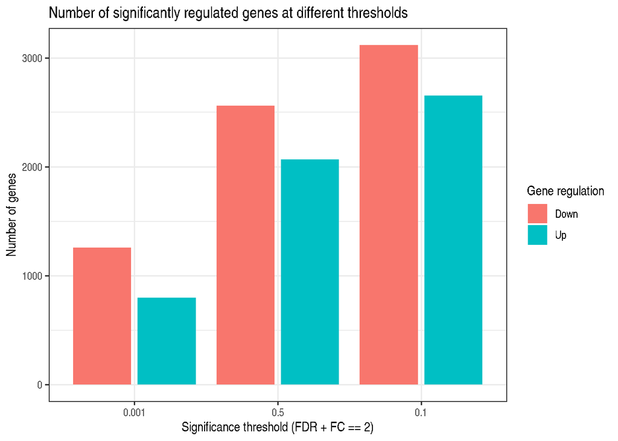

```r
fc_counts %>%
  filter(sig_label != "Unchanged") %>%
  ggplot(aes(sig_threshold, n)) +
  geom_col(aes(fill = sig_label), position = position_dodge2(0.9)) +
  labs(
    x = "Significance threshold (FDR + FC == 2)", y = "Number of genes",
    title = "Number of significantly regulated genes at different thresholds"
  ) +
  scale_x_discrete(
    labels = c("0.001", "0.5", "0.1")
  ) +
  scale_fill_discrete(name = "Gene regulation", labels = c("Down", "Up")) +
  theme_bw()
```

> Hacer un volcano plot (comparación FC vs Pvalue) y anotar en el volcano plot los top 10 hacia arriba y hacia abajo. Elegir un threshold de significancia. Anotar con geom_text o geom_label.

Vamos a filtrar únicamente los genes etiquetados con significancia a un threshold de FDR = 0.001:

```r
fc_001 <- fc_data %>%
  filter(sig_threshold == "sig_001")
```

Definamos como los top 10 a los genes que hayan sido etiquetados como “Up-” o “Down-regulated” y que tengan el mayor valor de fold change (o menor para el caso de los genes regulados hacia abajo).

```r
fc_001_top10_up <- fc_001 %>%
  filter(sig_label == "Up-regulated") %>%
  arrange(-logFC) %>%
  head(10)

fc_001_top10_down <- fc_001 %>%
  filter(sig_label == "Down-regulated") %>%
  arrange(logFC) %>%
  head(10)

## Join in a single tibble
top10 <- bind_rows(fc_001_top10_up, fc_001_top10_down)
```

Un volcano plot es un gráfico de dispersión con el logFC en el eje x y el -log10 del P-value en el eje y.

En el gráfico de abajo graficamos primero el dataframe “fc_001” y le agregamos otra capa de geom con los datos en “top10” (la línea con `geom_text_repel` del paquete `ggrepel`).

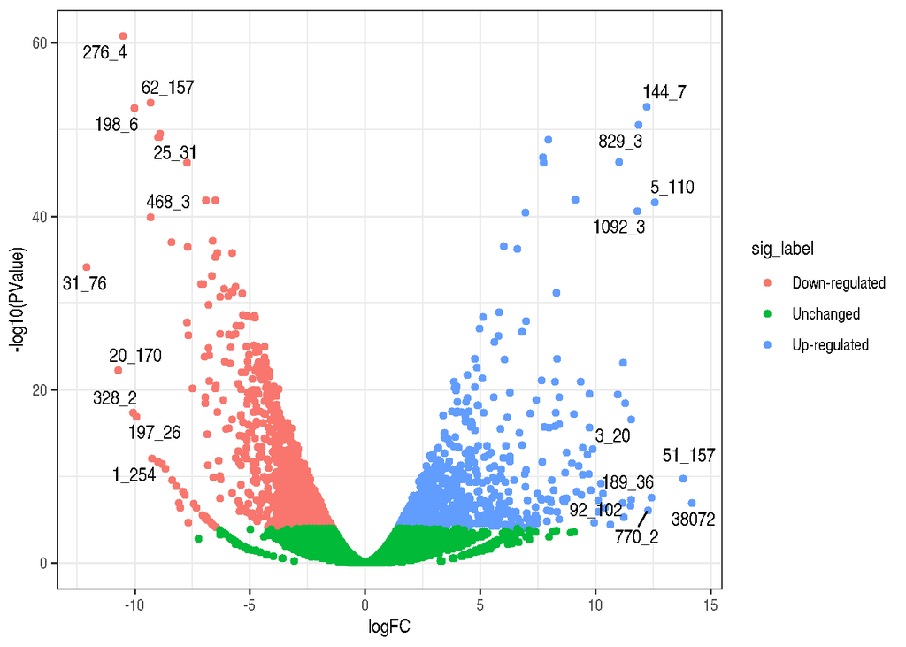

```r
fc_001 %>%
  ggplot(aes(logFC, -log10(PValue))) +
  geom_point(aes(color = sig_label)) +
  geom_text_repel(
    data = top10, mapping = aes(logFC, -log10(PValue), label = Genes)
  ) +
  theme_bw()
```

## Ejercicio 1.3

> De los top 10 UP y DOWN obtener los datos de expresión de TPM.Graficar las medias con las barras de error (SD)

Para este ejercicio necesitamos hacer match entre los identificadores en la columna “Genes” de “top10” y los identificadores en la columna “Cpapaya_ID” de “mat”.

```r
mat$Genes <- mat$Cpapaya_ID %>%
  sub("^.+_", "", .) %>%
  sub("\\.", "_", .)

mat[,c("Genes", "Cpapaya_ID")] %>%
  head()
```

```
## # A tibble: 6 × 2
##   Genes   Cpapaya_ID
##   <chr>   <chr>
## 1 23646   evm.TU.contig_23646
## 2 23646_1 evm.TU.contig_23646.1
## 3 23646_2 evm.TU.contig_23646.2
## 4 23646_4 evm.TU.contig_23646.4
## 5 23646_5 evm.TU.contig_23646.5
## 6 23646_6 evm.TU.contig_23646.6
```

Ahora podemos unir los dos dataframes con `left_join`:

```r
top10_new <- left_join(top10, mat, by = "Genes")
glimpse(top10_new)
```

```
## Rows: 20
## Columns: 25
## $ Genes         <chr> "38072", "51_157", "5_110", "189_36", "770_2", "144_7", …
## $ logFC         <dbl> 14.168409, 13.782210, 12.568871, 12.430357, 12.269867, 1…
## $ PValue        <dbl> 1.230169e-07, 1.789329e-10, 2.343958e-42, 2.938375e-08, …
## $ FDR           <dbl> 2.728613e-06, 7.165868e-09, 2.887894e-39, 7.770741e-07, …
## $ sig_threshold <chr> "sig_001", "sig_001", "sig_001", "sig_001", "sig_001", "…
## $ sig_label     <chr> "Up-regulated", "Up-regulated", "Up-regulated", "Up-regu…
## $ Cpapaya_ID    <chr> "evm.TU.contig_38072", "evm.TU.supercontig_51.157", "evm…
## $ `L-CNa`       <dbl> 0.0000000, 0.0000000, 0.0000000, 0.0000000, 0.0000000, 0…
## $ `L-CNb`       <dbl> 0.00000000, 0.00000000, 0.00000000, 0.00000000, 0.000000…
## $ `L-10a`       <dbl> 0.08433479, 0.06892634, 4.39468119, 0.05480475, 0.000000…
## $ `L-10b`       <dbl> 0.04923748, 0.20120754, 0.41985199, 0.12798741, 0.000000…
## $ `L-20a`       <dbl> 2.424940e-01, 1.783701e+00, 4.169996e+01, 1.772822e-01, …
## $ `L-20b`       <dbl> 2.791465e+02, 1.729611e+02, 4.623308e+01, 2.704035e+01, …
## $ `S-CNa`       <dbl> 0.00000000, 0.00000000, 0.11290034, 0.00000000, 0.000000…
## $ `S-CNb`       <dbl> 0.04377814, 0.00000000, 0.00000000, 0.00000000, 0.027032…
## $ `S-10a`       <dbl> 0.05191329, 0.00000000, 0.04918543, 0.01686786, 0.032056…
## $ `S-10b`       <dbl> 0.04256877, 0.00000000, 0.00000000, 0.00000000, 0.000000…
## $ `S-20a`       <dbl> 0.00000000, 0.00000000, 0.47128773, 0.01795838, 0.136513…
## $ `S-20b`       <dbl> 0.05308871, 0.00000000, 0.35209357, 0.01724978, 0.065563…
## $ `R-CNa`       <dbl> 0.66926844, 25.41676805, 1.26820148, 2.75450876, 27.8542…
## $ `R-CNb`       <dbl> 0.58770953, 21.51885743, 0.05568275, 0.64926669, 12.0484…
## $ `R-10a`       <dbl> 0.8463244, 20.5038483, 23.4828385, 0.9428260, 48.1910588…
## $ `R-10b`       <dbl> 1.0202176, 32.1541061, 10.3306307, 1.0151971, 38.2316859…
## $ `R-20a`       <dbl> 3.59997951, 30.14508280, 206.02508801, 2.99612204, 239.2…
## $ `R-20b`       <dbl> 3.6613281, 18.4096579, 154.3677513, 0.2844821, 61.239307…
```

En la línea de código de abajo creamos un tibble en formato tidy:

```r
top10_tidy <- top10_new %>%
  select(Cpapaya_ID, sig_label, starts_with("L-")) %>%
  pivot_longer(
    names_to = "Replicate", values_to = "TPM", cols = `L-CNa`:last_col()
  ) %>%
  arrange(sig_label) %>%
  mutate(
    Sample =
      factor(sub("a|b$", "", Replicate), levels = c("L-CN", "L-10", "L-20")),
    # sig_label = factor(sig_label, levels = c("Up-regulated", "Down-regulated")),
    Cpapaya_ID = fct_inorder(Cpapaya_ID)
  ) %>%
  select(sig_label, Cpapaya_ID, Sample, TPM, -Replicate)
head(top10_tidy)
```

```
## # A tibble: 6 × 4
##   sig_label      Cpapaya_ID               Sample    TPM
##   <chr>          <fct>                    <fct>   <dbl>
## 1 Down-regulated evm.TU.supercontig_31.76 L-CN   45.8
## 2 Down-regulated evm.TU.supercontig_31.76 L-CN   35.2
## 3 Down-regulated evm.TU.supercontig_31.76 L-10    0
## 4 Down-regulated evm.TU.supercontig_31.76 L-10    0.578
## 5 Down-regulated evm.TU.supercontig_31.76 L-20    0
## 6 Down-regulated evm.TU.supercontig_31.76 L-20    0
```

Ahora creamos un resumen con `summarise` (media, desviacíon estándar y error estándar):

```r
top10_summary <- top10_tidy %>%
  group_by(sig_label, Cpapaya_ID, Sample) %>%
  summarise(
    mean = mean(TPM),
    sd = sd(TPM),
    se = sd(TPM)/sqrt(length(TPM))
  ) %>%
  ungroup()
head(top10_summary)
```

```
## # A tibble: 6 × 6
##   sig_label      Cpapaya_ID                Sample   mean     sd     se
##   <chr>          <fct>                     <fct>   <dbl>  <dbl>  <dbl>
## 1 Down-regulated evm.TU.supercontig_31.76  L-CN   40.5   7.50   5.30
## 2 Down-regulated evm.TU.supercontig_31.76  L-10    0.289 0.409  0.289
## 3 Down-regulated evm.TU.supercontig_31.76  L-20    0     0      0
## 4 Down-regulated evm.TU.supercontig_20.170 L-CN   12.7   0.0983 0.0695
## 5 Down-regulated evm.TU.supercontig_20.170 L-10    2.36  1.25   0.884
## 6 Down-regulated evm.TU.supercontig_20.170 L-20    0     0      0
```

Podermos graficar las barras de error con `geom_errorbar`:

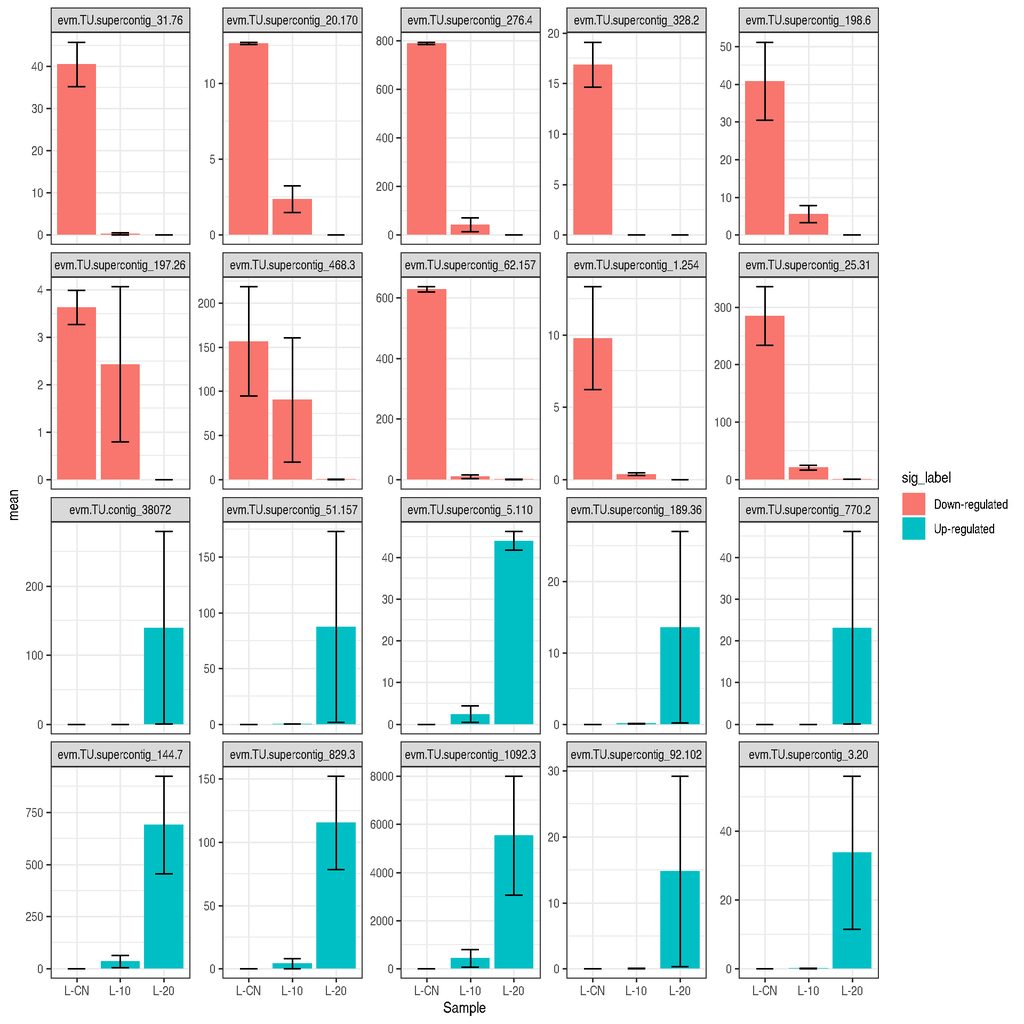

```r
top10_summary %>%
  ggplot(aes(Sample, mean)) +
  geom_col(aes(fill = sig_label)) +
  geom_errorbar(
    aes(ymin = mean - se, ymax = mean + se), width = 0.4
    ) +
  facet_wrap(~Cpapaya_ID, scales = "free_y") +
  theme_bw()
```